# ggparty

Alejandra Figueroa Tirado y Frances N. Alley Figueroa

2023-04-12

# Paquete ggParty: Graphic partying

## Origen de paquete

El creador de este paquete fue Martin Borkovec. Niyaz Madin junto a él fueron los autores de el mismo. En adición, este paquete fue publicado en el 2019.

## Introducción

Ya hemos utilizado gráficos “geom_histogram”, “geom_boxplot” y “geom_violin”. Además, hemos utiizado los diagramas de “heatmap” para mostrar las relaciones entre las características numéricas.

Algunas veces sucede que la relación lineal general entre dos variables no es tan significativa hasta que encontramos la forma correcta de establecer una diferencia en nuestro “dataset”. Por consecuencia, la capacidad de otras características tiene el rol de modificar o controlar la relación entre nuestras variables deseadas.

El paquete ‘ggparty’ se introducé para ayudarnos con este problema. GGparty tiene como objetivo extender la funcionalidad de ggplot2 en el paquete partykit. Provee las herramientas necesarias para crear visualizaciones claramente estructuradas y altamente personalizables para modelos de regresión con estructura de árbol de la clase ‘party’.

### Paquetes incluidos al instalar “ggparty” y activarlo ya que son requeridos.

```r
library(ggparty)
library(ggplot2)
library(partykit)
library(grid)
library(libcoin)
library(mvtnorm)
```

### Paquetes necesarios que no se instalan automáticamente

```r
library(dplyr)
library(party)
```

## Class ‘party’

Para que los datos se representen como modelos de regresión con estructura de árbol se utilizan dos “basic building blocks”: “splits of class ‘partysplit’” y “nodes of class ‘partynode’”. Lo resultante se puede asocir a un objeto de clase ‘party’.

```r
WeatherPlay
```

1. Usar la función ‘partysplit’ para definir los métodos de división para la columna:

```r
sp_o <- partysplit(1L, index = 1:3)
sp_h <- partysplit(3L, breaks = 75)
sp_w <- partysplit(4L, index = 1:2)
```

2. Usar la función ‘partynode’ para definir los métodos de división para los nodos del árbol:

```r
pn <- partynode(1L, split = sp_o, kids = list(
  partynode(2L, split = sp_h, kids = list(
    partynode(3L, info = "yes"),
    partynode(4L, info = "no"))),
  partynode(5L, info = "yes"),
  partynode(6L, split = sp_w, kids = list(
    partynode(7L, info = "yes"),
    partynode(8L, info = "no")))))
py <- party(pn, WeatherPlay)
```

Al final, ‘party’ dividira los datos en la forma más básica de árbol

```r
print(py)
```

[output not shown]

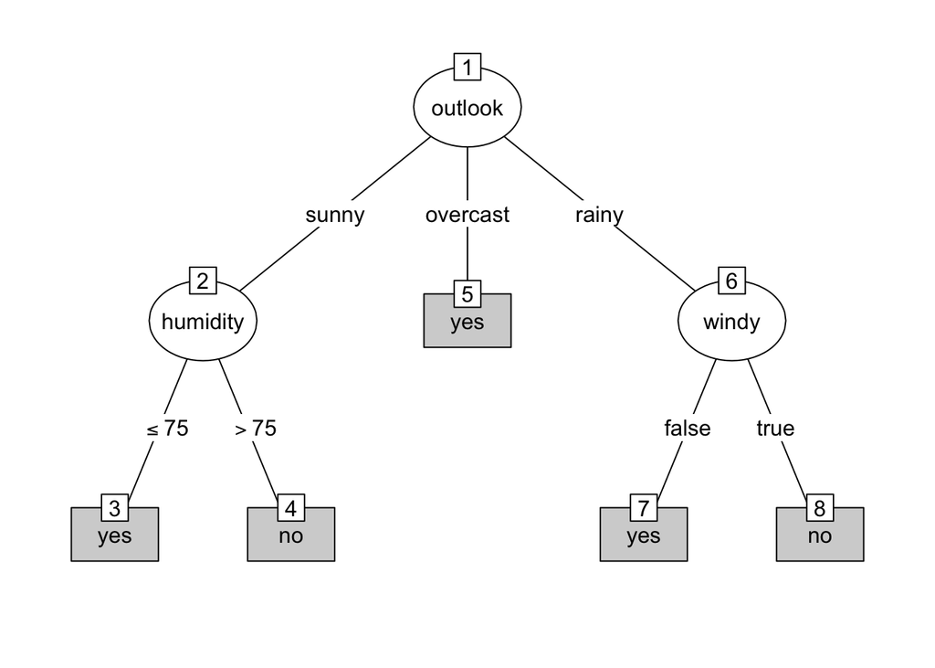

```r
plot(py)
```

## Utilizar ‘ggparty’ para visualizar el árbol

- geom_edge() dibuja los bordes entre los nodos
- geom_edge_label() etiqueta los bordes con las divisiones correspondientes
- geom_node_label() etiqueta los nodos con la variable dividida, información del nodo o cualquier otra cosa.
- geom_node_plot() crea un ggplot personalizado en la ubicación del nodo

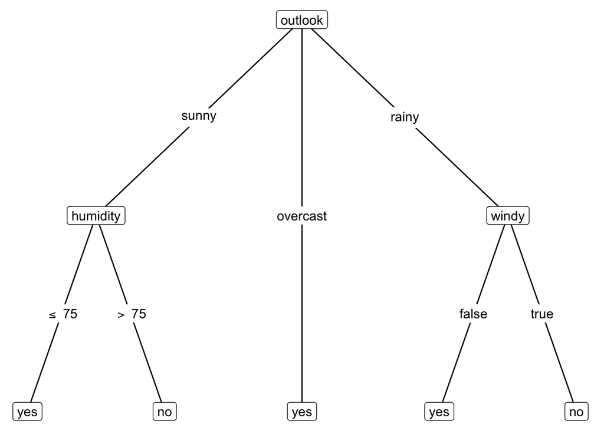

```r
ggparty(py) +
  geom_edge() +
  geom_edge_label() +
  geom_node_label(aes(label = splitvar),
                  ids = "inner") +
  geom_node_label(aes(label = info),
                  ids = "terminal")
```

## Costumizar el árbol

Cambiar el color y tamaño de los nodos

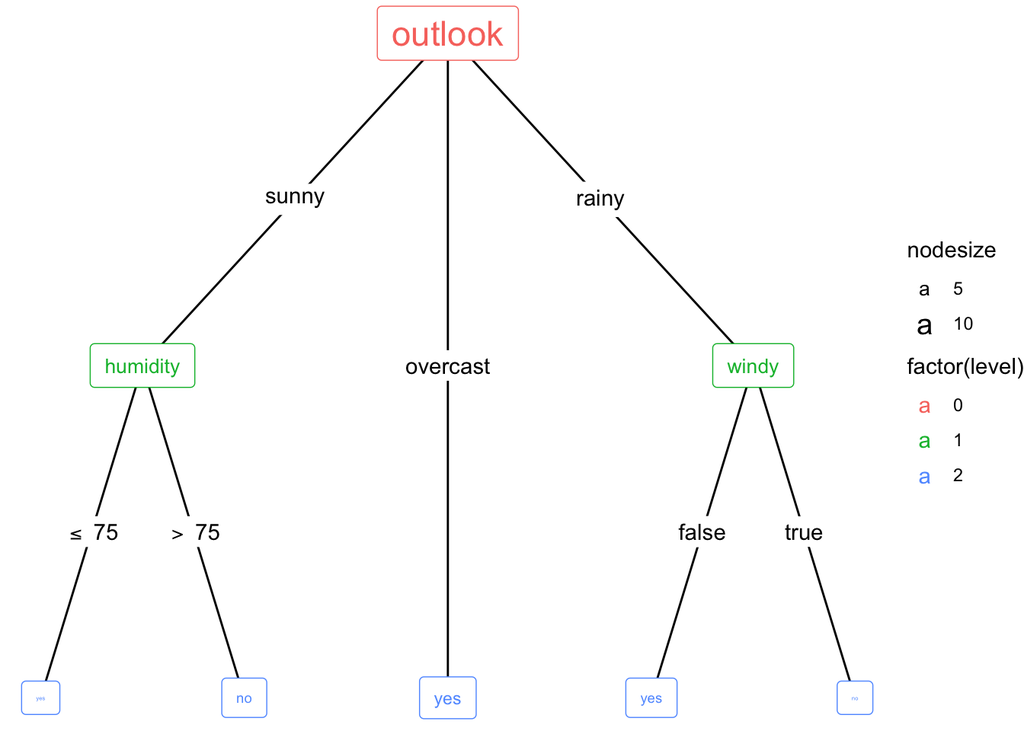

```r
ggparty(py) +
  geom_edge() +
  geom_edge_label() +
  # map color to level and size to nodesize for all nodes
  geom_node_splitvar(aes(col = factor(level),
                         size = nodesize)) +
  geom_node_info(aes(col = factor(level),
                     size = nodesize))
```

## Añadir nuevos “plots” al árbol

```r
n1 <- partynode(id = 1L, split = sp_o, kids = lapply(2L:4L, partynode))
t2 <- party(n1,
            data = WeatherPlay,
            fitted = data.frame(
              "(fitted)" = fitted_node(n1, data = WeatherPlay),
              "(response)" = WeatherPlay$play,
              check.names = FALSE),
            terms = terms(play ~ ., data = WeatherPlay)
)
t2 <- as.constparty(t2)

t2
```

```
##
## Model formula:
## play ~ outlook + temperature + humidity + windy
##
## Fitted party:
## [1] root
## |   [2] outlook in sunny: no (n = 5, err = 40.0%)
## |   [3] outlook in overcast: yes (n = 4, err = 0.0%)
## |   [4] outlook in rainy: yes (n = 5, err = 40.0%)
##
## Number of inner nodes:    1
## Number of terminal nodes: 3
```

Para visualizar la distribución de la variables usaremos la función geom_node_plot(). Nos permite mostrar los datos de cada nodo en su gráfica separada.

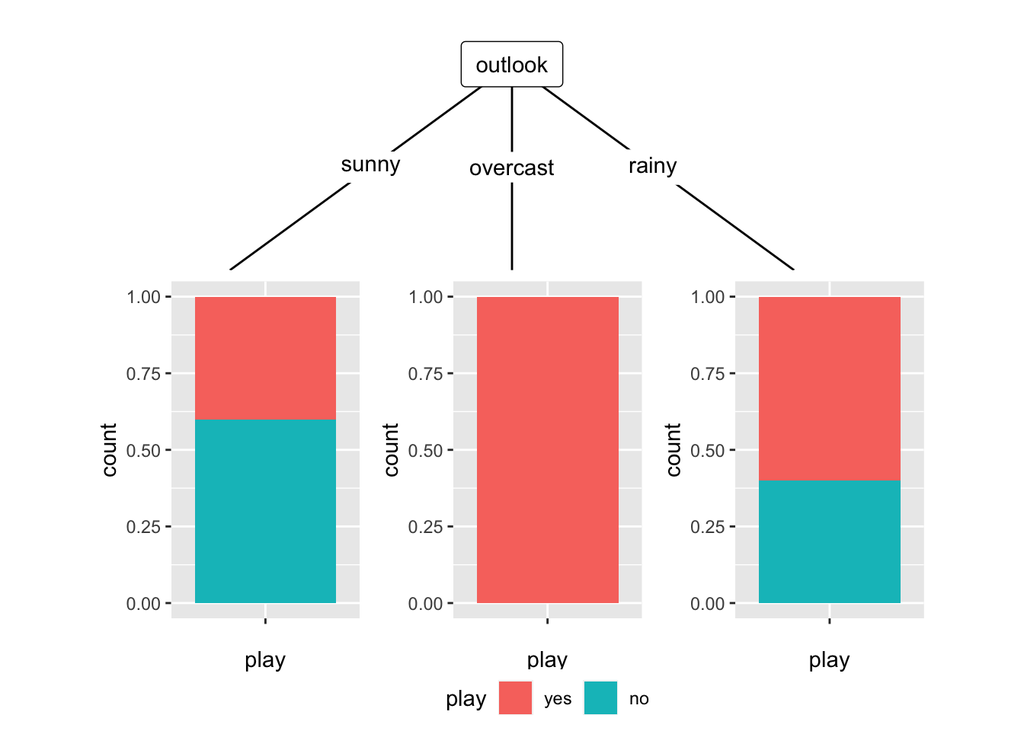

```r
ggparty(t2) +
  geom_edge() +
  geom_edge_label() +
  geom_node_splitvar() +
  geom_node_plot(gglist = list(geom_bar(aes(x = "", fill = play),
                                        position = position_fill()),
                               xlab("play")))
```

### Aplicación: Númerica vs Númerica

```r
data("TeachingRatings", package = "AER")
head(TeachingRatings)
```

```
##   minority age gender credits     beauty eval division native tenure students
## 1      yes  36 female    more  0.2899157  4.3    upper    yes    yes       24
## 2       no  59   male    more -0.7377322  4.5    upper    yes    yes       17
## 3       no  51   male    more -0.5719836  3.7    upper    yes    yes       55
## 4       no  40 female    more -0.6779634  4.3    upper    yes    yes       40
## 5       no  31 female    more  1.5097940  4.4    upper    yes    yes       42
## 6       no  62   male    more  0.5885687  4.2    upper    yes    yes      182
##   allstudents prof
## 1          43    1
## 2          20    2
## 3          55    3
## 4          46    4
## 5          48    5
## 6         282    6
```

#### Mecanismo para escoger variables si hay demasiadas

```r
TeachingRatings
tr <- subset(TeachingRatings, credits == "more")
tr_tree <- lmtree(eval ~ beauty | minority + age + gender + division + native +
                    tenure, data = tr, weights = students, caseweights = FALSE)

tr
```

[output not shown]

#### Usando “predict” para formar un “trend line”

Se utiliza “predict” para mostrar la “prediction line” o “trend line” de las gráficas. El “trend line” es una linea utilizada para mostrar el patrón o manifestación general de los valores.

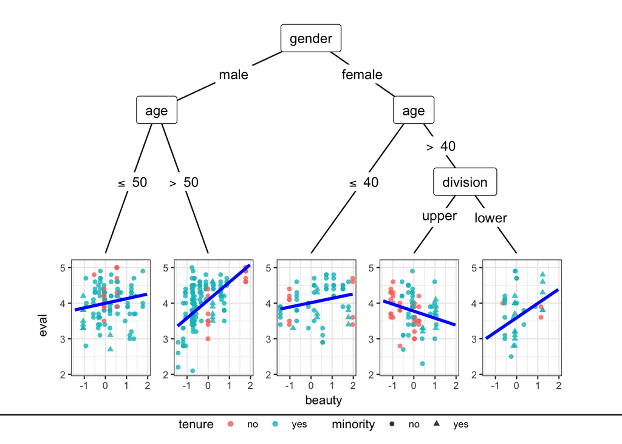

```r
ggparty(tr_tree) +
  geom_edge() +
  geom_edge_label() +
  geom_node_splitvar() +
  geom_node_plot(gglist = list(geom_point(aes(x = beauty,
                                             y = eval,
                                             col = tenure,
                                             shape = minority),
                                         alpha = 0.8),
                              theme_bw(base_size = 10)),
                shared_axis_labels = TRUE,
                legend_separator = TRUE,
                # predict based on variable
                predict = "beauty",
                # graphical parameters for geom_line of predictions
                predict_gpar = list(col = "blue",
                                   size = 1.2)
                )
```

Para hacer que nuestro “plot” más bonito, usamos el paquete de ggparty. Un patrón interesante ocurre en el nodo 8.

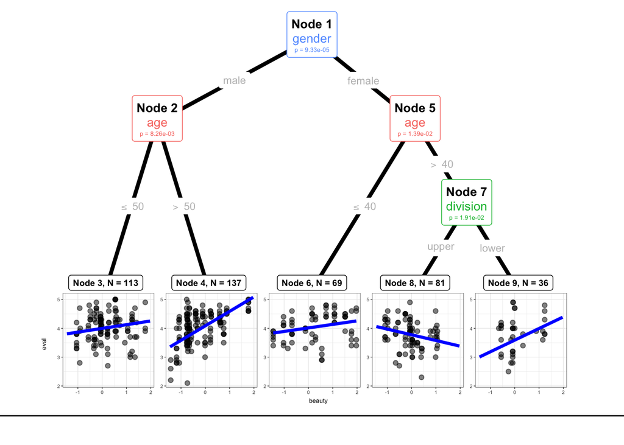

```r
ggparty(tr_tree,
        terminal_space = 0.3,
        add_vars = list(p.value = "$node$info$p.value")) +
  geom_edge(size = 1.5) +
  geom_edge_label(colour = "grey", size = 3) +
  geom_node_plot(gglist = list(geom_point(aes(x = beauty,
                                             y = eval),
                                         alpha = 0.5),
                              theme_bw(base_size = 5)),
                scales = "fixed",
                id = "terminal",
                shared_axis_labels = T,
                shared_legend = T,
                legend_separator = T,
                predict = "beauty",
                predict_gpar = list(col = "blue",
                                   size = 1.2)
                ) +
  geom_node_label(aes(col = splitvar),
                  line_list = list(aes(label = paste("Node", id)),
                                   aes(label = splitvar),
                                   aes(label = paste("p =", formatC(p.value, format = "e", digits = 2)))),
                  line_gpar = list(list(size = 10, col = "black", fontface = "bold"),
                                   list(size = 10),
                                   list(size = 5)),
                  ids = "inner") +
  geom_node_label(aes(label = paste0("Node ", id, ", N = ", nodesize)),
                  fontface = "bold",
                  ids = "terminal",
                  size = 2.5,
                  nudge_y = 0.02) +
  theme(legend.position = "none")
```

### Nuestro ‘ggparty’

#### Datos

```r
data("CollegeDistance", package = "AER")

head(CollegeDistance)
```

[output not shown]

#### Selección de variables

```r
cd <- subset(CollegeDistance)
cd_tree <- lmtree(score ~ education | income + gender +
                    urban, data = cd, weights = distance, caseweights = FALSE)

head(cd)
```

```
##   gender ethnicity score fcollege mcollege home urban unemp wage distance
## 1   male     other 39.15      yes       no  yes   yes   6.2 8.09      0.2
## 2 female     other 48.87       no       no  yes   yes   6.2 8.09      0.2
## 3   male     other 48.74       no       no  yes   yes   6.2 8.09      0.2
## 4   male      afam 40.40       no       no  yes   yes   6.2 8.09      0.2
## 5 female     other 40.48       no       no   no   yes   5.6 8.09      0.4
## 6   male     other 54.71       no       no  yes   yes   5.6 8.09      0.4
##   tuition education income region
## 1 0.88915        12   high  other
## 2 0.88915        12    low  other
## 3 0.88915        12    low  other
## 4 0.88915        12    low  other
## 5 0.88915        13    low  other
## 6 0.88915        12    low  other
```

#### Diagrama ‘ggparty’

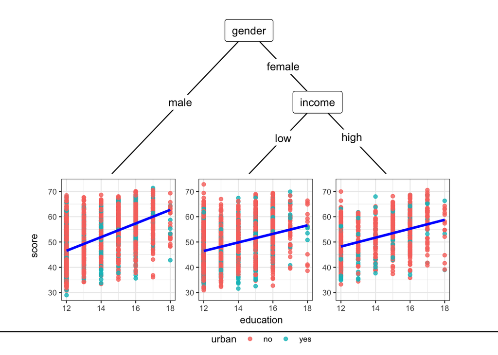

```r
ggparty(cd_tree) +
  geom_edge() +
  geom_edge_label() +
  geom_node_splitvar() +
  geom_node_plot(gglist = list(geom_point(aes(x = education,
                                             y = score,
                                             col = urban),
                                         alpha = 0.8),
                              theme_bw(base_size = 10)),
                shared_axis_labels = TRUE,
                legend_separator = TRUE,
                # predict based on variable
                predict = "education",
                # graphical parameters for geom_line of predictions
                predict_gpar = list(col = "blue",
                                   size = 1.2)
                )
```

### Diagrama ‘ggparty’ con más detalles

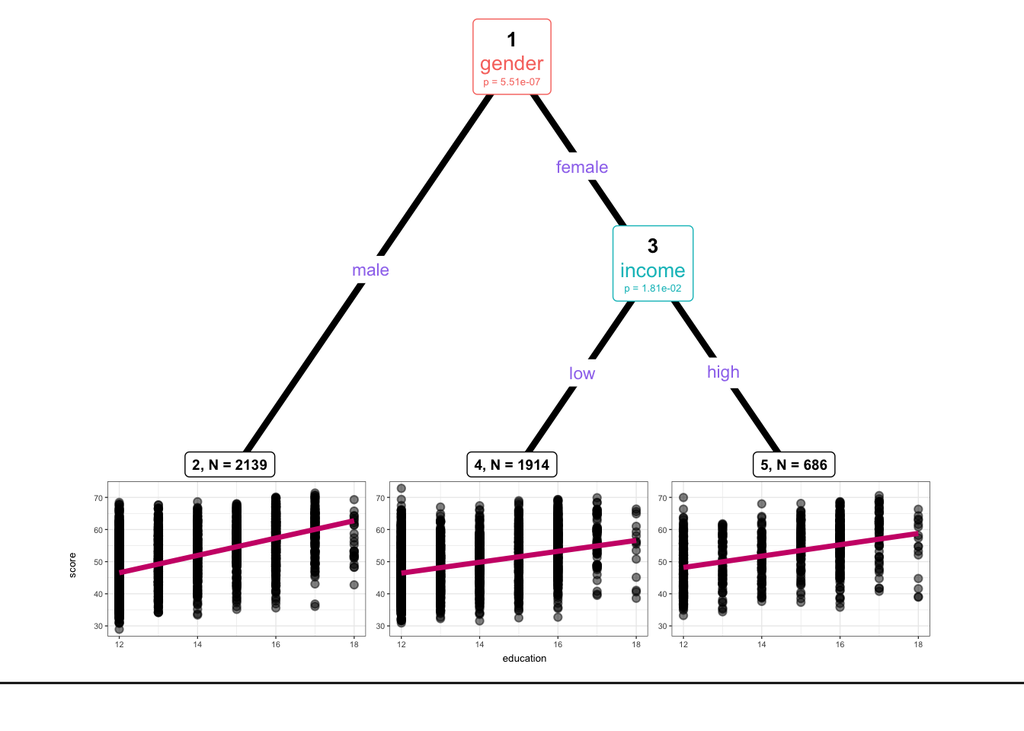

```r
ggparty(cd_tree,
        terminal_space = 0.3,
        add_vars = list(p.value = "$node$info$p.value")) +
  geom_edge(size = 1.5) +
  geom_edge_label(colour = "mediumpurple2", size = 3) +
  geom_node_plot(gglist = list(geom_point(aes(x = education,
                                             y = score),
                                         alpha = 0.5),
                              theme_bw(base_size = 5)),
                scales = "fixed",
                id = "terminal",
                shared_axis_labels = T,
                shared_legend = T,
                legend_separator = T,
                predict = "education",
                predict_gpar = list(col = "deeppink3",
                                   size = 1.2)
                ) +
  geom_node_label(aes(col = splitvar),
                  line_list = list(aes(label = paste(id)),
                                   aes(label = splitvar),
                                   aes(label = paste("p =", formatC(p.value, format = "e", digits = 2)))),
                  line_gpar = list(list(size = 10, col = "black", fontface = "bold"),
                                   list(size = 10),
                                   list(size = 5)),
                  ids = "inner") +
  geom_node_label(aes(label = paste0(id, ", N = ", nodesize)),
                  fontface = "bold",
                  ids = "terminal",
                  size = 2.5,
                  nudge_y = 0.02)+
  theme(legend.position = "none")
```